# Kelompok 4_Praktikum_Pekan 8

Angga Fathan Rofiqy

06 April, 2024

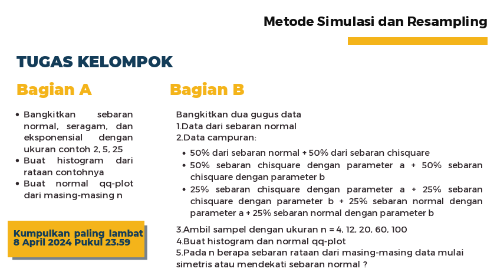

**Kelompok 4 Pararel 2**

| Nama | NIM |
| --- | --- |
| Angga Fathan Rofiqy | G1401211006 |
| Gladys Adya Zafira | G1401211014 |
| Kheni Hikmah Lestari | G1401211029 |

# Bagian A

## Poin 1

> Bangkitkan sebaran **Normal**, **Seragam**, dan **Eksponensial** dengan ukuran contoh **2, 5, 25**

Berikut merupakan hasil pembangkitan masing-masing serbaran dengan ukuran contoh 2, 5, 25:

### **Normal**

```r
sample_size <- c(2, 5, 25)

norm_samples <- lapply(sample_size, function(n) rnorm(n))

print(norm_samples)
```

```
## [[1]]
## [1] -2.0549694  0.5454831
##
## [[2]]
## [1] -0.8398288 -0.7795405 -0.3675568  1.3279582 -0.3904268
##
## [[3]]
##  [1]  0.12244145  0.38745557 -0.82535684  1.02087485  1.56548766  0.06957406
##  [7] -0.16818620 -1.17978204  0.26352966  2.53504486 -0.38138364  0.88832450
## [13]  2.09849444 -0.34197630 -0.22382204 -0.45412456  0.97216657 -1.21883158
## [19]  0.25931445  0.47008668  1.16203030  0.73999118  1.17803631 -0.90378480
## [25] -1.38740004
```

Sebaran Normal dengan ukuran contoh (n) **2, 5, 25**

### **Seragam**

```r
unif_samples <- lapply(sample_size, function(n) runif(n))

print(unif_samples)
```

```
## [[1]]
## [1] 0.7516004 0.6098073
##
## [[2]]
## [1] 0.5489342 0.4847680 0.5538747 0.9604952 0.2832968
##
## [[3]]
##  [1] 0.672423905 0.429141947 0.645269877 0.602069331 0.909281317 0.368605219
##  [7] 0.064337822 0.224186642 0.449826635 0.873049902 0.708128065 0.595338758
## [13] 0.311195627 0.004131785 0.253372908 0.901385644 0.327964966 0.154823604
## [19] 0.710690337 0.454089752 0.034216080 0.570050162 0.866222492 0.923956651
## [25] 0.830258557
```

Sebaran Seragam dengan ukuran contoh (n) **2, 5, 25**

### **Eksponensial**

```r
exp_samples <- lapply(sample_size, function(n) rexp(n))

print(exp_samples)
```

```
## [[1]]
## [1] 0.1903727 0.6040509
##
## [[2]]
## [1] 0.0918627562 0.0434581991 0.0009565636 0.0834057569 2.4031569603
##
## [[3]]
##  [1] 0.27972301 0.09299928 0.17066022 1.65837570 2.48753047 0.04346248
##  [7] 0.01183520 2.96458556 1.63758590 0.90037893 0.08009026 1.07752135
## [13] 2.39965557 0.54842987 1.06454209 1.05416949 0.64553781 2.65642989
## [19] 0.04591820 0.22710480 0.07843281 0.16761939 0.14096184 1.59663476
## [25] 0.60595174
```

Sebaran Eksponensial dengan ukuran contoh (n) **2, 5, 25**

## Poin 2

> Buat **histogram** dari **rataan contoh**nya

```r
# Menghitung rata-rata dari masing-masing sampel
norm_means <- sapply(norm_samples, mean)
unif_means <- sapply(unif_samples, mean)
exp_means <- sapply(exp_samples, mean)
```

### **Rata-rata contoh** masing-masing sebaran:

#### **Normal**

```r
print(norm_means)
```

```
## [1] -0.7547432 -0.2098789  0.2659282
```

#### **Seragam**

```r
print(unif_means)
```

```
## [1] 0.6807039 0.5662738 0.5153607
```

#### **Eksponensial**

```r
print(exp_means)
```

```
## [1] 0.3972118 0.5245680 0.9054455
```

### **Histogram dari rata-rata contoh**

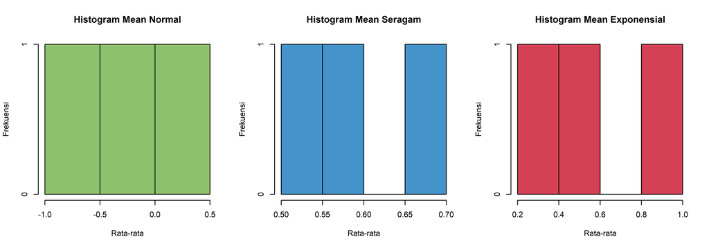

```r
par(mfrow = c(1, 3))
hist(norm_means, main = "Histogram Mean Normal",
     xlab = "Rata-rata", ylab = "Frekuensi", col = "#8DC16D")
hist(unif_means, main = "Histogram Mean Seragam",
     xlab = "Rata-rata", ylab = "Frekuensi", col = "#4493CA")
hist(exp_means, main = "Histogram Mean Exponensial",
     xlab = "Rata-rata", ylab = "Frekuensi", col = "#D44155")
```

## Poin 3

> Buat **normal qq-plot** dari masing-masing n

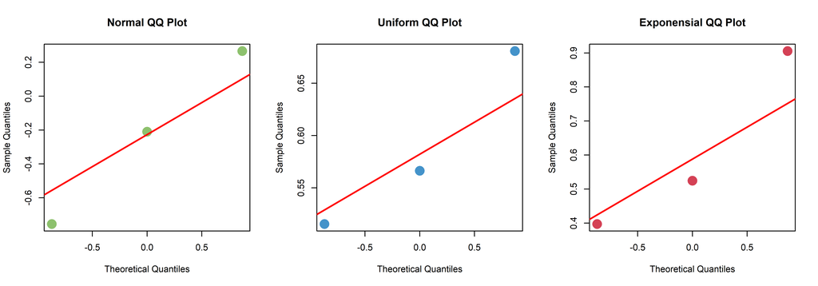

```r
par(mfrow = c(1, 3))
qqnorm(norm_means, main = "Normal QQ Plot", col = "#8DC16D", lwd = 7,
       xlab = "Theoretical Quantiles", ylab = "Sample Quantiles")
qqline(norm_means, col = "red", lwd=2)

qqnorm(unif_means, main = "Uniform QQ Plot", col = "#4493CA", lwd = 7,
       xlab = "Theoretical Quantiles", ylab = "Sample Quantiles")
qqline(unif_means, col = "red", lwd=2)

qqnorm(exp_means, main = "Exponensial QQ Plot", col = "#D44155", lwd = 7,
       xlab = "Theoretical Quantiles", ylab = "Sample Quantiles")
qqline(exp_means, col = "red", lwd=2)
```

# Bagian B

## Poin 1

> Bangkitkan **dua gugus data**
1. Data dari sebaran normal
2. Data campuran:
   - 50% dari sebaran normal + 50% dari sebaran chi-square
   - 50% sebaran chi-square dengan paramenter a + 50% sebaran chi-square dengan paramenter b
   - 25% sebaran chi-square dengan parameter a + 25% sebaran chi-suqare dengan parameter b + 25% sebaran normal dengan paramater a + 25% sebaran normal parameter b

### **Normal**

```r
norm_data <- rnorm(1000, mean = 0, sd = 1)
hist(norm_data, main = "Histogram Normal",
     xlab = "Nilai", ylab = "Frekuensi", col = "#4664AF")
```

[figure not shown]

### **Campuran 1**

> **50%** dari sebaran **normal** + **50%** dari sebaran **chi-square**

```r
csq_data <- rchisq(1000, df = 1)
mixed_data_1 <- c(norm_data[1:500], csq_data[1:500])
hist(mixed_data_1, main = "Histogram Campuran 1",
     xlab = "Nilai", ylab = "Frekuensi", col = "#9F4274")
```

[figure not shown]

### **Campuran 2**

> **50%** sebaran **chi-square** dengan paramenter **a + 50%** sebaran chi-square dengan paramenter **b**

```r
csq_data_a <- rchisq(500, df = 1)
csq_data_b <- rchisq(500, df = 2)
mixed_data_2 <- c(csq_data_a, csq_data_b)
hist(mixed_data_2, main = "Histogram Campuran 2",
     xlab = "Nilai", ylab = "Frekuensi", col = "#66C8CC")
```

[figure not shown]

### **Campuran 3**

```r
norm_data_a <- rnorm(250, mean = 0, sd = 1)
norm_data_b <- rnorm(250, mean = 1, sd = 1)
mixed_data_3 <- c(csq_data_a, csq_data_b, norm_data_a, norm_data_b)
hist(mixed_data_3, main = "Histogram Campuran 3",
     xlab = "Nilai", ylab = "Frekuensi", col = "#F8D054")
```

[figure not shown]